# Домашнее задание (титаник)

## 1. Загрузка данных

### Загрузим тренирововчную выборку

```python
# Python 2 and 3 compatibility
# pip install future
from __future__ import (absolute_import, division,
                        print_function, unicode_literals)
# отключим  предупреждения Anaconda
import warnings
warnings.simplefilter('ignore')
import pandas as pd
import numpy as np
%matplotlib inline
import matplotlib.pyplot as plt
import seaborn as sns
import matplotlib.pyplot as plt
import re
plt.rcParams['figure.figsize'] = (10, 6)
```

```python
titanic_data_train = pd.read_csv('train.csv')
titanic_data_train.head()
```

|  | PassengerId | Survived | Pclass | Name | Sex | Age | SibSp | Parch | Ticket | Fare | Cabin | Embarked |
| --- | --- | --- | --- | --- | --- | --- | --- | --- | --- | --- | --- | --- |
| 0 | 1 | 0 | 3 | Braund, Mr. Owen Harris | male | 22.0 | 1 | 0 | A/5 21171 | 7.2500 | NaN | S |
| 1 | 2 | 1 | 1 | Cumings, Mrs. John Bradley (Florence Briggs Th... | female | 38.0 | 1 | 0 | PC 17599 | 71.2833 | C85 | C |
| 2 | 3 | 1 | 3 | Heikkinen, Miss. Laina | female | 26.0 | 0 | 0 | STON/O2. 3101282 | 7.9250 | NaN | S |
| 3 | 4 | 1 | 1 | Futrelle, Mrs. Jacques Heath (Lily May Peel) | female | 35.0 | 1 | 0 | 113803 | 53.1000 | C123 | S |
| 4 | 5 | 0 | 3 | Allen, Mr. William Henry | male | 35.0 | 0 | 0 | 373450 | 8.0500 | NaN | S |

```python
titanic_data_train.describe()
```

|  | PassengerId | Survived | Pclass | Age | SibSp | Parch | Fare |
| --- | --- | --- | --- | --- | --- | --- | --- |
| count | 891.000000 | 891.000000 | 891.000000 | 714.000000 | 891.000000 | 891.000000 | 891.000000 |
| mean | 446.000000 | 0.383838 | 2.308642 | 29.699118 | 0.523008 | 0.381594 | 32.204208 |
| std | 257.353842 | 0.486592 | 0.836071 | 14.526497 | 1.102743 | 0.806057 | 49.693429 |
| min | 1.000000 | 0.000000 | 1.000000 | 0.420000 | 0.000000 | 0.000000 | 0.000000 |
| 25% | 223.500000 | 0.000000 | 2.000000 | 20.125000 | 0.000000 | 0.000000 | 7.910400 |
| 50% | 446.000000 | 0.000000 | 3.000000 | 28.000000 | 0.000000 | 0.000000 | 14.454200 |
| 75% | 668.500000 | 1.000000 | 3.000000 | 38.000000 | 1.000000 | 0.000000 | 31.000000 |
| max | 891.000000 | 1.000000 | 3.000000 | 80.000000 | 8.000000 | 6.000000 | 512.329200 |

```python
titanic_data_train.info()
```

```
<class 'pandas.core.frame.DataFrame'>
RangeIndex: 891 entries, 0 to 890
Data columns (total 12 columns):
PassengerId    891 non-null int64
Survived       891 non-null int64
Pclass         891 non-null int64
Name           891 non-null object
Sex            891 non-null object
Age            714 non-null float64
SibSp          891 non-null int64
Parch          891 non-null int64
Ticket         891 non-null object
Fare           891 non-null float64
Cabin          204 non-null object
Embarked       889 non-null object
dtypes: float64(2), int64(5), object(5)
memory usage: 83.6+ KB
```

### Загрузим тестовую выборку

```python
titanic_data_test = pd.read_csv('test.csv')
titanic_data_test.head()
```

|  | PassengerId | Pclass | Name | Sex | Age | SibSp | Parch | Ticket | Fare | Cabin | Embarked |
| --- | --- | --- | --- | --- | --- | --- | --- | --- | --- | --- | --- |
| 0 | 892 | 3 | Kelly, Mr. James | male | 34.5 | 0 | 0 | 330911 | 7.8292 | NaN | Q |
| 1 | 893 | 3 | Wilkes, Mrs. James (Ellen Needs) | female | 47.0 | 1 | 0 | 363272 | 7.0000 | NaN | S |
| 2 | 894 | 2 | Myles, Mr. Thomas Francis | male | 62.0 | 0 | 0 | 240276 | 9.6875 | NaN | Q |
| 3 | 895 | 3 | Wirz, Mr. Albert | male | 27.0 | 0 | 0 | 315154 | 8.6625 | NaN | S |
| 4 | 896 | 3 | Hirvonen, Mrs. Alexander (Helga E Lindqvist) | female | 22.0 | 1 | 1 | 3101298 | 12.2875 | NaN | S |

```python
titanic_data_test.describe()
```

|  | PassengerId | Pclass | Age | SibSp | Parch | Fare |
| --- | --- | --- | --- | --- | --- | --- |
| count | 418.000000 | 418.000000 | 332.000000 | 418.000000 | 418.000000 | 417.000000 |
| mean | 1100.500000 | 2.265550 | 30.272590 | 0.447368 | 0.392344 | 35.627188 |
| std | 120.810458 | 0.841838 | 14.181209 | 0.896760 | 0.981429 | 55.907576 |
| min | 892.000000 | 1.000000 | 0.170000 | 0.000000 | 0.000000 | 0.000000 |
| 25% | 996.250000 | 1.000000 | 21.000000 | 0.000000 | 0.000000 | 7.895800 |
| 50% | 1100.500000 | 3.000000 | 27.000000 | 0.000000 | 0.000000 | 14.454200 |
| 75% | 1204.750000 | 3.000000 | 39.000000 | 1.000000 | 0.000000 | 31.500000 |
| max | 1309.000000 | 3.000000 | 76.000000 | 8.000000 | 9.000000 | 512.329200 |

```python
titanic_data_test.info()
```

```
<class 'pandas.core.frame.DataFrame'>
RangeIndex: 418 entries, 0 to 417
Data columns (total 11 columns):
PassengerId    418 non-null int64
Pclass         418 non-null int64
Name           418 non-null object
Sex            418 non-null object
Age            332 non-null float64
SibSp          418 non-null int64
Parch          418 non-null int64
Ticket         418 non-null object
Fare           417 non-null float64
Cabin          91 non-null object
Embarked       418 non-null object
dtypes: float64(2), int64(4), object(5)
memory usage: 36.0+ KB
```

```python
titanic_data_test[titanic_data_test['Age'].isnull()].head()
```

|  | PassengerId | Pclass | Name | Sex | Age | SibSp | Parch | Ticket | Fare | Cabin | Embarked |
| --- | --- | --- | --- | --- | --- | --- | --- | --- | --- | --- | --- |
| 10 | 902 | 3 | Ilieff, Mr. Ylio | male | NaN | 0 | 0 | 349220 | 7.8958 | NaN | S |
| 22 | 914 | 1 | Flegenheim, Mrs. Alfred (Antoinette) | female | NaN | 0 | 0 | PC 17598 | 31.6833 | NaN | S |
| 29 | 921 | 3 | Samaan, Mr. Elias | male | NaN | 2 | 0 | 2662 | 21.6792 | NaN | C |
| 33 | 925 | 3 | Johnston, Mrs. Andrew G (Elizabeth Lily" Watson)" | female | NaN | 1 | 2 | W./C. 6607 | 23.4500 | NaN | S |
| 36 | 928 | 3 | Roth, Miss. Sarah A | female | NaN | 0 | 0 | 342712 | 8.0500 | NaN | S |

### Создадим единый фрейм для обеих выборок

```python
titanic_data = titanic_data_train.append(titanic_data_test)
```

```python
titanic_data.info()
```

```
<class 'pandas.core.frame.DataFrame'>
Int64Index: 1309 entries, 0 to 417
Data columns (total 12 columns):
Age            1046 non-null float64
Cabin          295 non-null object
Embarked       1307 non-null object
Fare           1308 non-null float64
Name           1309 non-null object
Parch          1309 non-null int64
PassengerId    1309 non-null int64
Pclass         1309 non-null int64
Sex            1309 non-null object
SibSp          1309 non-null int64
Survived       891 non-null float64
Ticket         1309 non-null object
dtypes: float64(3), int64(4), object(5)
memory usage: 132.9+ KB
```

```python
titanic_data.describe()
```

|  | Age | Fare | Parch | PassengerId | Pclass | SibSp | Survived |
| --- | --- | --- | --- | --- | --- | --- | --- |
| count | 1046.000000 | 1308.000000 | 1309.000000 | 1309.000000 | 1309.000000 | 1309.000000 | 891.000000 |
| mean | 29.881138 | 33.295479 | 0.385027 | 655.000000 | 2.294882 | 0.498854 | 0.383838 |
| std | 14.413493 | 51.758668 | 0.865560 | 378.020061 | 0.837836 | 1.041658 | 0.486592 |
| min | 0.170000 | 0.000000 | 0.000000 | 1.000000 | 1.000000 | 0.000000 | 0.000000 |
| 25% | 21.000000 | 7.895800 | 0.000000 | 328.000000 | 2.000000 | 0.000000 | 0.000000 |
| 50% | 28.000000 | 14.454200 | 0.000000 | 655.000000 | 3.000000 | 0.000000 | 0.000000 |
| 75% | 39.000000 | 31.275000 | 0.000000 | 982.000000 | 3.000000 | 1.000000 | 1.000000 |
| max | 80.000000 | 512.329200 | 9.000000 | 1309.000000 | 3.000000 | 8.000000 | 1.000000 |

### Пропуски данных

1. Поле Cabin - пропущенно 1014 значений. Заполнение - не известно 2. Поле Age - пропущено 263 значения. Заполнение - по среднему. Частичное заполнение по префиксам (Master, Miss?) 3. Поле Embarked - пропущено 2 значения. Заполнение - вероятно можно пренебречь 4. Поле Fare - пропущено 1 значение. Заполнение - вероятно можно пренебречь 5. Поле Survived - пропущено 418 значений. Заполнение - цель этой домашней работы

## 2. Предобработка данных

### Заполним Age

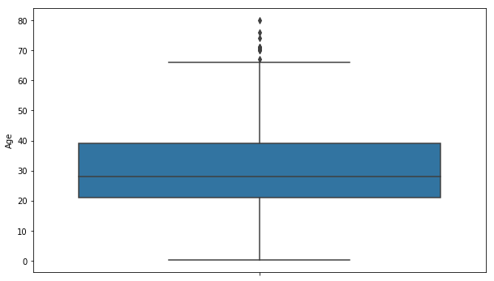

```python
sns.boxplot(y='Age', data=titanic_data);
```

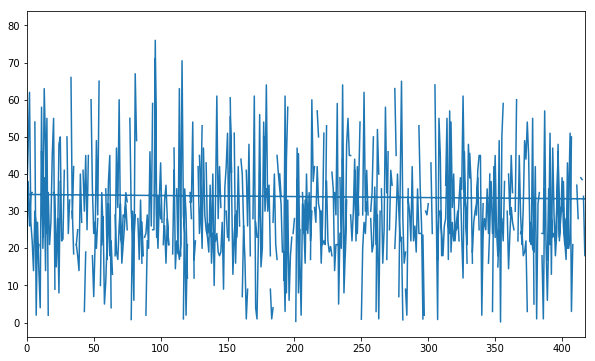

```python
titanic_data['Age'].plot()
```

Возраст колеблется от 0 до 80 лет.50% выборки люди в возрасте от 20 до 40 лет. Выбросы - несколько значений свыше 68 лет, можно было бы заполнить пропуски по среднему значению, но попробуем узнать что-нибудь еще о данных.

```python
titanic_data.sort_values(by='Age').head()
```

|  | Age | Cabin | Embarked | Fare | Name | Parch | PassengerId | Pclass | Sex | SibSp | Survived | Ticket |
| --- | --- | --- | --- | --- | --- | --- | --- | --- | --- | --- | --- | --- |
| 354 | 0.17 | NaN | S | 20.5750 | Dean, Miss. Elizabeth Gladys Millvina"" | 2 | 1246 | 3 | female | 1 | NaN | C.A. 2315 |
| 201 | 0.33 | NaN | S | 14.4000 | Danbom, Master. Gilbert Sigvard Emanuel | 2 | 1093 | 3 | male | 0 | NaN | 347080 |
| 803 | 0.42 | NaN | C | 8.5167 | Thomas, Master. Assad Alexander | 1 | 804 | 3 | male | 0 | 1.0 | 2625 |
| 755 | 0.67 | NaN | S | 14.5000 | Hamalainen, Master. Viljo | 1 | 756 | 2 | male | 1 | 1.0 | 250649 |
| 469 | 0.75 | NaN | C | 19.2583 | Baclini, Miss. Helene Barbara | 1 | 470 | 3 | female | 2 | 1.0 | 2666 |

Наблюдение: приставки Master и Miss используются для несовершеннолетних пассажиров. Чтобы это проверить выделим столбец с приставками

```python
titanic_data['Prefix'] = [re.sub('[, .]', '',re.search(r', \w+.', name).group()) for name in titanic_data['Name']]
titanic_data.head()
```

|  | Age | Cabin | Embarked | Fare | Name | Parch | PassengerId | Pclass | Sex | SibSp | Survived | Ticket | Prefix |
| --- | --- | --- | --- | --- | --- | --- | --- | --- | --- | --- | --- | --- | --- |
| 0 | 22.0 | NaN | S | 7.2500 | Braund, Mr. Owen Harris | 0 | 1 | 3 | male | 1 | 0.0 | A/5 21171 | Mr |
| 1 | 38.0 | C85 | C | 71.2833 | Cumings, Mrs. John Bradley (Florence Briggs Th... | 0 | 2 | 1 | female | 1 | 1.0 | PC 17599 | Mrs |
| 2 | 26.0 | NaN | S | 7.9250 | Heikkinen, Miss. Laina | 0 | 3 | 3 | female | 0 | 1.0 | STON/O2. 3101282 | Miss |
| 3 | 35.0 | C123 | S | 53.1000 | Futrelle, Mrs. Jacques Heath (Lily May Peel) | 0 | 4 | 1 | female | 1 | 1.0 | 113803 | Mrs |
| 4 | 35.0 | NaN | S | 8.0500 | Allen, Mr. William Henry | 0 | 5 | 3 | male | 0 | 0.0 | 373450 | Mr |

Уникальные приставки:

```python
print(set(titanic_data['Prefix']))
```

```
{'Ms', 'Major', 'Mme', 'Don', 'Mlle', 'Jonkheer', 'Master', 'Rev', 'Dr', 'Sir', 'the', 'Dona', 'Mrs', 'Miss', 'Lady', 'Col', 'Capt', 'Mr'}
```

Выведем возраст пассажиров с приставками Master и Miss

```python
print(sorted(titanic_data[(titanic_data['Prefix'] == 'Master')]['Age'].unique()))
```

```
[0.33000000000000002, 0.41999999999999998, 0.67000000000000004, 0.75, 0.82999999999999996, 0.92000000000000004, 1.0, 2.0, 3.0, 4.0, 5.0, 6.0, 7.0, 11.0, nan, 8.0, 9.0, 10.0, 11.5, 12.0, 13.0, 14.5]
```

```python
print(sorted(titanic_data[(titanic_data['Prefix'] == 'Miss')]['Age'].unique()))
```

[output not shown]

Вывод: Master - мужчины в возрасте до 18 лет, Miss - женщины любого возраста. Отсутствующие данные с приставкой Master можно заполнить по среднему возрасту Master

```python
titanic_data.reset_index(drop=True, inplace=True)
```

```python
mean_master_age = titanic_data[titanic_data['Prefix'] == 'Master']['Age'].mean()
print('Средний возраст пасссажиров с приставкой Master: ', mean_master_age)
titanic_data.loc[(titanic_data['Age'].isnull()) & (titanic_data['Prefix'] == 'Master'), 'Age'] = mean_master_age
titanic_data.info()
```

```
Средний возраст пасссажиров с приставкой Master:  5.482641509433961
<class 'pandas.core.frame.DataFrame'>
RangeIndex: 1309 entries, 0 to 1308
Data columns (total 13 columns):
Age            1054 non-null float64
Cabin          295 non-null object
Embarked       1307 non-null object
Fare           1308 non-null float64
Name           1309 non-null object
Parch          1309 non-null int64
PassengerId    1309 non-null int64
Pclass         1309 non-null int64
Sex            1309 non-null object
SibSp          1309 non-null int64
Survived       891 non-null float64
Ticket         1309 non-null object
Prefix         1309 non-null object
dtypes: float64(3), int64(4), object(6)
memory usage: 133.0+ KB
```

### Портрет среднего утопленника

Утопленник это:

```python
pd.crosstab(titanic_data['Sex'], titanic_data['Survived']) # мужчина
```

| Survived Sex | 0 | 1 |
| --- | --- | --- |
| female | 81 | 233 |
| male | 468 | 109 |

```python
print('Средний возраст утопленника: ', round(titanic_data[titanic_data['Survived'] == 0]['Age'].mean()))
```

```
Средний возраст утопленника:  31
```

```python
print('Средняя цена билета утопленника: ', round(titanic_data[titanic_data['Survived'] == 0]['Fare'].mean()))
```

[output not shown]

```python
print(titanic_data[titanic_data['Survived']==0]['Embarked'].max())
# Город посадки Southampton
```

```
S
```

```python
print('Социальный класс выжившего: ', titanic_data[titanic_data['Survived']==1]['Pclass'].max())
```

```
Социальный класс выжившего:  3
```

```python
pd.crosstab(titanic_data['SibSp'], titanic_data['Survived']).sort_values(by=[0], ascending = False).head()
```

| Survived SibSp | 0 | 1 |
| --- | --- | --- |
| 0 | 398 | 210 |
| 1 | 97 | 112 |
| 2 | 15 | 13 |
| 4 | 15 | 3 |
| 3 | 12 | 4 |

```python
pd.crosstab(titanic_data['Parch'], titanic_data['Survived']).sort_values(by=[0], ascending = False).head()
# На борту нет родственников
```

| Survived Parch | 0 | 1 |
| --- | --- | --- |
| 0 | 445 | 233 |
| 1 | 53 | 65 |
| 2 | 40 | 40 |
| 4 | 4 | 0 |
| 5 | 4 | 1 |